# Guinea worm mitochondrial DNA genomics

## Alignment commands (Linux)

This method directly aligns the FASTA files to the mitochondrial reference genome.

```
conda activate ngs_align
GW_DIR="/mnt/c/Users/jribado/Desktop/guineaWorm_genomic"
# create alignment index
bwa index $GW_DIR/mt_reference/DmedinensisMitochondrionComplete.fasta

# run alignments for all files, convery sam to bam files
find $GW_DIR -maxdepth 1 -name *.fasta | sed -e 's/.*ALL_\(.*\).fasta/\1/' | xargs -i{} echo 'bwa mem -t 4 '$GW_DIR/'mt_reference/DmedinensisMitochondrionComplete.fasta '$GW_DIR/'ALL_{}.fasta > bwaAlign_{}.sam; \
cat bwaAlign_{}.sam | samtools view -S -b | samtools sort --threads 4 > bwaAlign_{}.bam; \
samtools index bwaAlign_{}.bam' | sh
conda deactivate

samtools view  '/home/jribado/Dropbox (IDM)/Data, Dynamics, and Analytics Folder/Projects/Guinea Worm Genetics in Chad/gw_bwaAlign/2020_newSeqs/alignments/bwaAlign_ND3-5.bam' |  awk -v OFS='\t' '{print $1,$4,$10}'
```

## Identify variants

```r
project_dir <- "/home/jribado/Dropbox (IDM)/Data, Dynamics, and Analytics Folder/Projects/Guinea Worm Genetics in Chad/gw_bwaAlign/2020_newSeqs"
gw_dir <- paste(project_dir, "alignments", sep="/")
genes  <- c("co3", "cytB", "nd35")
```

### Create standard sequences

First, read in the alignment files and generate equilength sequences that account for minimum and maximum alignment positions of samples per gene.

```r
gene_sequences <- lapply(setNames(genes, genes), function(i){
  new_sequence <- seq_match(gw_dir, paste0("bwaAlign_", i, ".txt"))
  names(new_sequence) <- c("worm", i)
  return(new_sequence)
})
gene_sequences_df <- Reduce(function(...) merge(..., all="TRUE", by="worm"), gene_sequences)
# write.table(gene_sequences_df, paste(project_dir, "202003_geneSequences.txt", sep="/"), sep="\t", quote = F, row.names = F)
```

### Count variants at each positon

```r
# get the length of the gene sequences
gene_lengths <- list(co3=nchar(gene_sequences_df$co3[1]),
                     cytB=nchar(gene_sequences_df$cytB[1]),
                     nd35=nchar(gene_sequences_df$nd35[2]))

variants_list <- lapply(setNames(genes, genes), function(i){
  fasta2snpIden(gene_sequences_df, i, 1, gene_lengths[[i]], 2)
})
variants_df <- dplyr::bind_rows(variants_list)
# write.table(dplyr::select(gene_seqs_df, worm, co3_sequence, cytB_sequence, nd35_sequence),
#  paste(project_dir, "202003_geneSequences.txt", sep="/"), sep="\t", quote = F, row.names = F)
#write.table(gene_seqs_df, paste(project_dir, "202003_geneSequences_missing1.txt", sep="/"), sep="\t", quote = F, row.names = F)
```

### Identify sequencing abnormalities

How many variant positions may be driven by outlier worms? Outlier worms are worms that have a large proportion of singleton variants compared to the sampled population, or have a large number of missing positions for any gene. The positions from outlier worms will be ignored when creating barcodes.

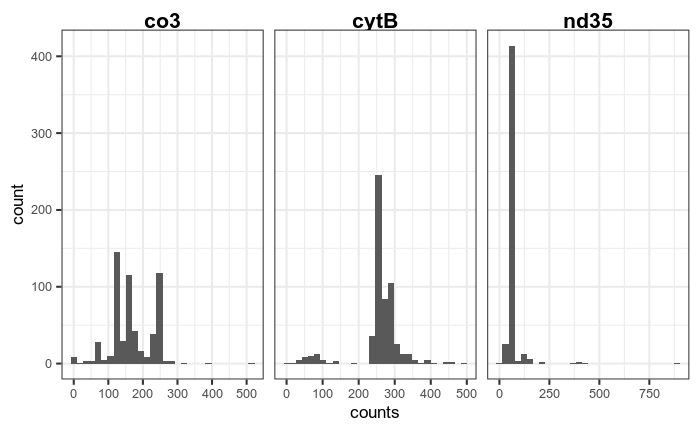

```r
missing_counts <- do.call(rbind, lapply(genes, function(j){cbind.data.frame(
    gene= j, worm = gene_sequences_df[,1],
    counts = unlist(lapply(gene_sequences_df[,j], function(i){stringr::str_count(i, "\\-")})))
}))
missing_counts %>% ggplot(aes(x=counts)) + geom_histogram() + facet_grid(~gene, scales="free")
```

```r
# calculate outliers
outlier_worms <- missing_counts %>%
  group_by(gene) %>%
  filter((abs(counts - median(counts)) > 2*sd(counts)))
outlier_worms
```

| gene | worm | counts |
| --- | --- | --- |

```r
outlier_worm <- dplyr::filter(missing_counts, gene == "nd35" & counts > 750) %>% .[["worm"]]
```

Using standard +- 2 SD from the median, no worms are statistical outliers. The worm missing >750 bp in the gene sequence is missing about 40% of bases, and will be removed since it will skew the genomic similarity metrics.

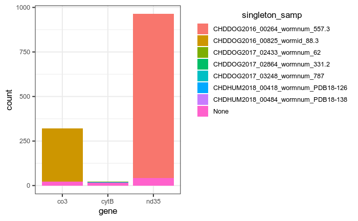

```r
variant_counts <- dplyr::filter(variants_df, variant == "T") %>%
  dplyr::group_by(gene, singleton_samp) %>%
  dplyr::summarise(count = n())
variant_counts %>% ggplot(aes(x=gene, y=count, fill=singleton_samp)) + geom_bar(stat="identity")
```

We can see two worms are driving more of the variation across genes. Singleton variants in these two worms will be ignored.

```r
sing_outlier <- dplyr::filter(variant_counts, count > 50) %>% .[["singleton_samp"]]
```

### Filter worms on genomic availability

All three genes need to be sequenced to create a barcode. Remove any worms missing a gene, or if still retained, in one of the categories above.

```r
# gene_sequences_df <- read.delim(paste(project_dir, "202003_geneSequences.txt", sep="/"), sep="\t")
filtered_worms <- na.omit(gene_sequences_df) %>%
  dplyr::filter(!worm %in% c(miss_outlier, sing_outlier))
```

Dropping worms missing any of the three genes retains 459 out of the possible 595.

## Generate barcodes

```r
barcode_list <- lapply(setNames(genes, genes), function(y){
  sequence2barcode(y, filtered_worms[["worm"]], filtered_worms[[y]], variants_df)
})
barcode_df <- Reduce(function(...) merge(..., all="TRUE", by="worm"), gene_seqs_list)
barcode_df <- tidyr::unite(barcode_df, "full_barcode", co3:nd35, sep="", remove=FALSE)
write.table(barcode_df, paste(project_dir, "202003_geneBarcodes.txt", sep="/"), sep="\t", quote = F, row.names = F)
```

Within the bounds of the genes, the variant barcode with singletons included is 86 basepairs long with 41 unique haplotypes.